# HW4-Predictive regression modeling with R

#### Normality of residuals

Create a histogram of the residuals for your top 3 models. You may have to tweak the axes scales to make a nice histogram.

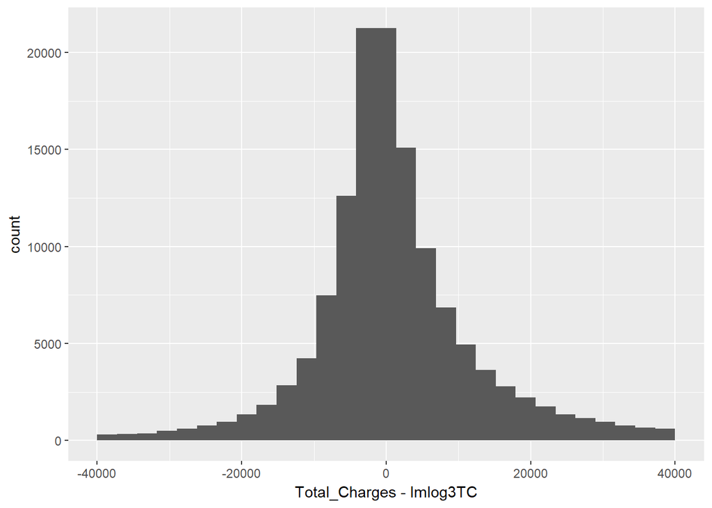

```r
#Make Histograms of Residuals
ggplot(pred_train, aes(x = Total_Charges - lmlog3TC)) +
  geom_histogram() +
  scale_x_continuous(limits = c(-40000, 40000))
```

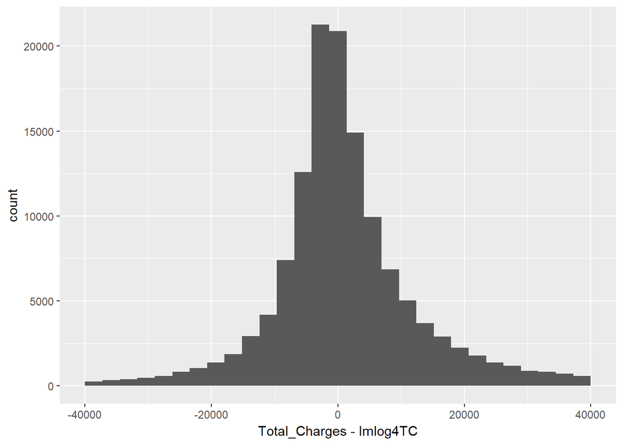

```r
ggplot(pred_train, aes(x = Total_Charges - lmlog4TC)) +
  geom_histogram() +
  scale_x_continuous(limits = c(-40000, 40000))
```

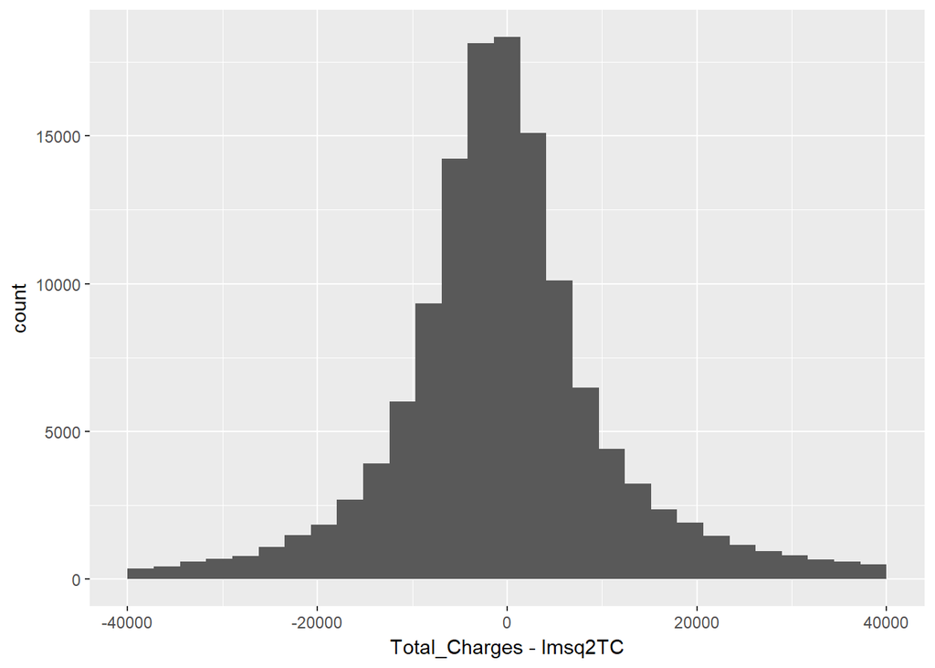

```r
ggplot(pred_train, aes(x = Total_Charges - lmsq2TC)) +
  geom_histogram() +
  scale_x_continuous(limits = c(-40000, 40000))
```

#### Constant variance

Make an appropriate plot to check for constant variance (homeskedasticity) for your top model. Don't remember what kind of plot to make? See my notes on residual analysis or any intro stats book.

### ANSWER

*The first two models appear to be fairly homoskedastic, although they do fan out a little bit from right to left. The third model, lmsq2 is definately heteroskedastic. This could mean that the model is not reliable because one of the assumptions of linear regression is that the variance of the residuals is constant. The presence of heteroscedasticity suggests that the variance is not constant.*

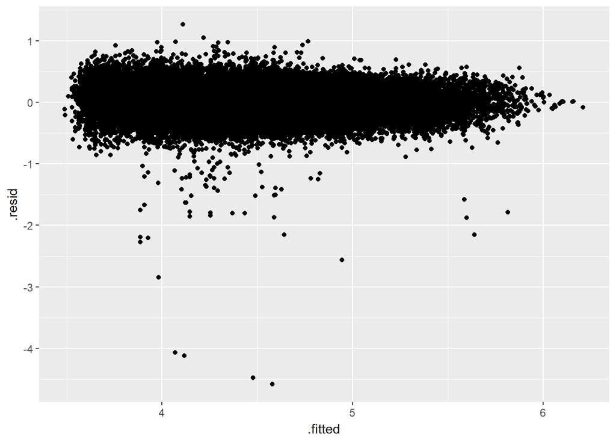

```r
ggplot(charges_lmlog3, aes(x = .fitted, y = .resid)) +
  geom_point()
```

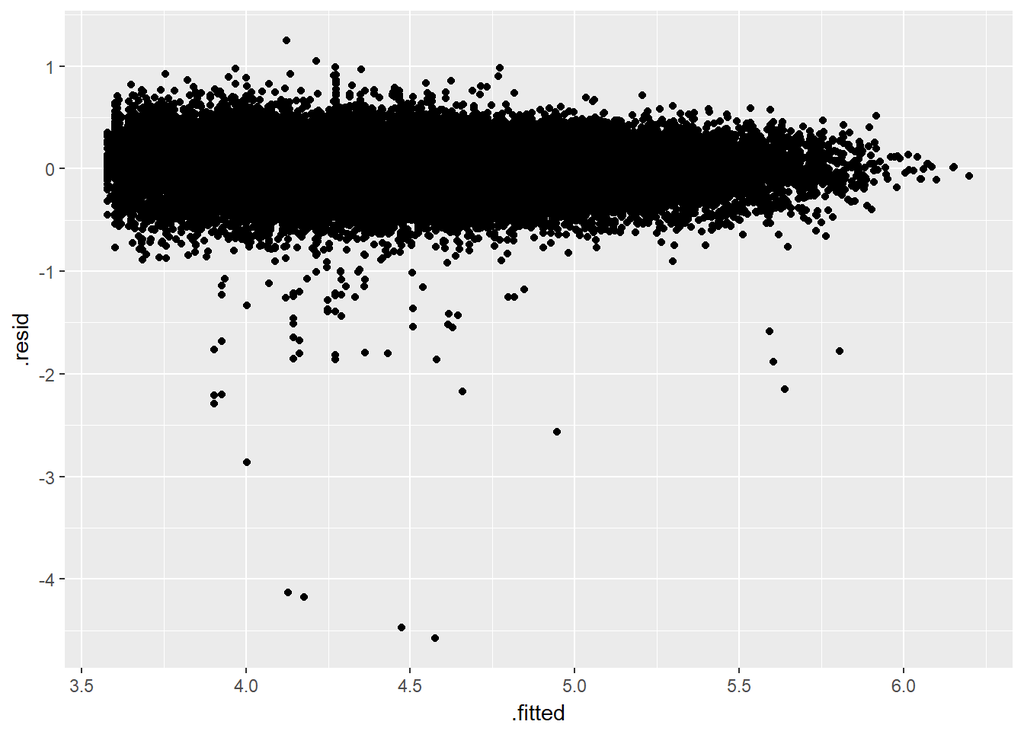

```r
ggplot(charges_lmlog4, aes(x = .fitted, y = .resid)) +
  geom_point()
```

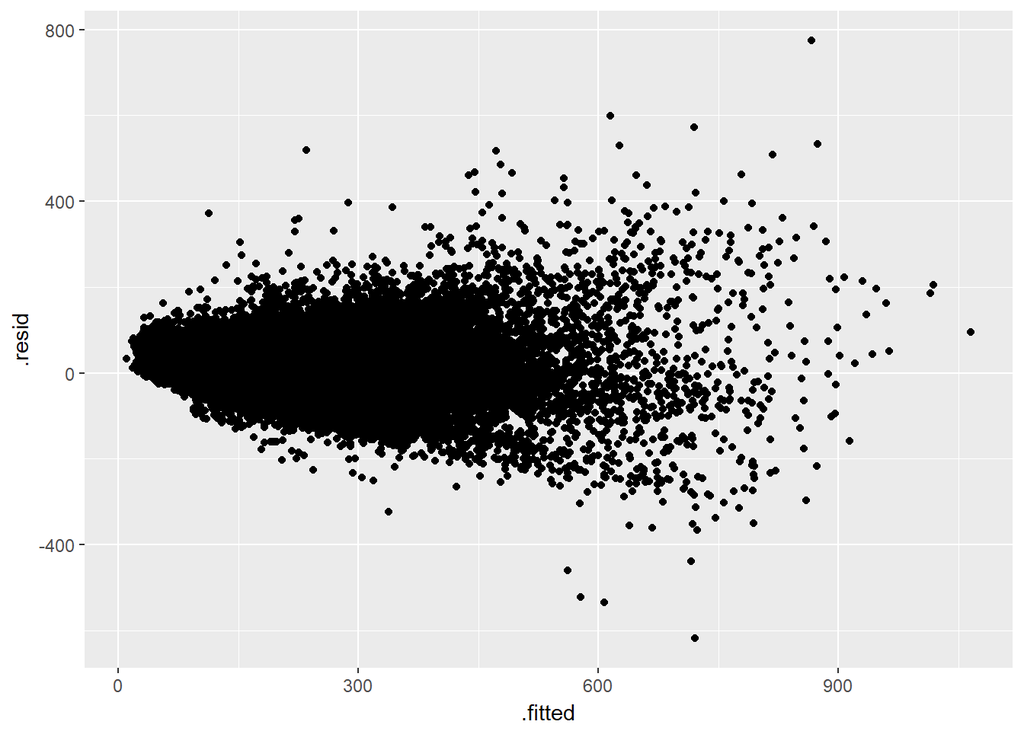

```r
ggplot(charges_lmsq2, aes(x = .fitted, y = .resid)) +
  geom_point()
```

### Make predictions for the test dataset

For each of your top 3 models, make predictions for `ipd_test`.

```r
pred_test <- data.frame(Total_Charges = ipd_test$Total_Charges,
                        lmlog3TC = 10**predict.glm(charges_lmlog3,ipd_test),
                        lmlog4TC = 10**predict(charges_lmlog4, ipd_test),
                        lmsq2TC = predict(charges_lmsq2, ipd_test)**2)
```

### Evaluate the predictions

Compute the MAD for each of the three models' predictions on the test data.

```r
median(abs(pred_test$Total_Charges - pred_test$lmlog3TC))
```

```
## [1] 5368.273
```

```r
median(abs(pred_test$Total_Charges - pred_test$lmlog4TC))
```

```
## [1] 5447.862
```

```r
median(abs(pred_test$Total_Charges - pred_test$lmsq2TC))
```

```
## [1] 5970.913
```

HINT: Obviously you can't use the residuals (or errors) directly but will have to compute them. They are simply the difference between the actual values and your predicted values.

So, for the model I mentioned earlier that had a MAD of 7270.340 for the training data, the MAD on the test data was 7335.559. Notice that MAD for test is higher than MAD for train.

**QUESTION:** Do you think it's typical that MAD for test would be higher than MAD for train? Why or why not?

**Answer:** *Yes, because the model was specifically fitted for the train data. When applied to the test data, the model is being used to predict based on data it has not seen yet.*

**QUESTION:** Which of your top 3 models had the lowest MAD for the test data?

**Answer:** *The 'charges_lmlog3' had the lowest MAD for the test data. It's MAD was 5368.273*

**QUESTION:** How do the MAD values for the test data compare to the MAD values for the training data?

```r
MAD_Table <- data.frame(Model = rbind('lmlog3', 'lmlog4', 'lmsq2'),
                        Train = rbind(median(abs(ipd_train$Total_Charges - 10**predict.glm(charges_lmlog3,ipd_train))),
                              median(abs(ipd_train$Total_Charges - 10**predict.glm(charges_lmlog4,ipd_train))),
                              median(abs(ipd_train$Total_Charges - predict.glm(charges_lmsq2,ipd_train)**2))),
                        Test = rbind(median(abs(pred_test$Total_Charges - pred_test$lmlog3TC)),
                              median(abs(pred_test$Total_Charges - pred_test$lmlog4TC)),
                              median(abs(pred_test$Total_Charges - pred_test$lmsq2TC))))
MAD_Table
```

```
##    Model    Train     Test
## 1 lmlog3 5322.044 5368.273
## 2 lmlog4 5379.915 5447.862
## 3  lmsq2 5932.768 5970.913
```

**Answer:** *The MAD values for the Test data are higher than those of the Train data.*

Finally, create some sort of plot which shows the MAD values for both train and test for your top 3 models. One plot.

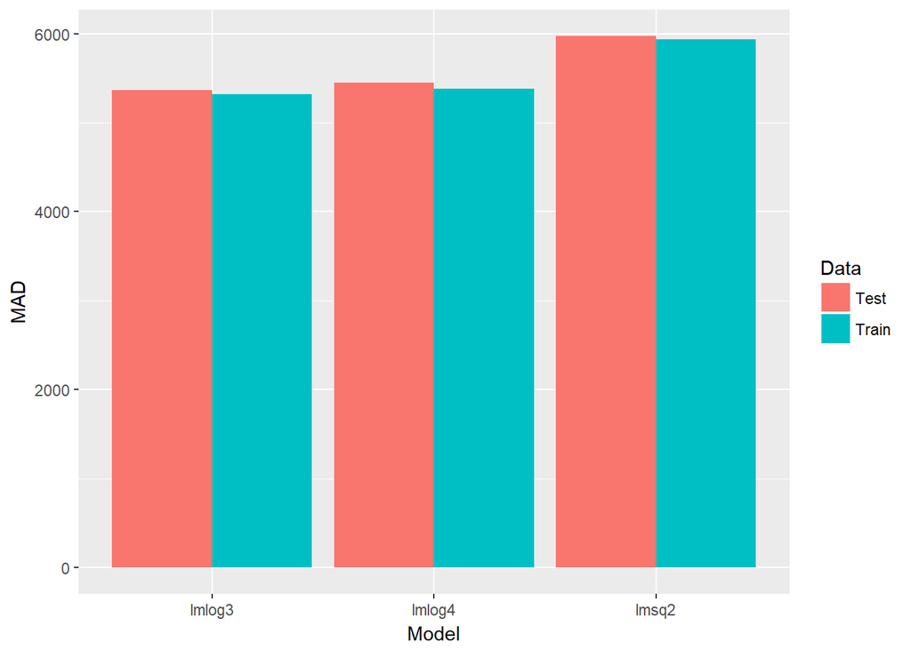

```r
MAD_Table2 <- data.frame(Model = rbind('lmlog3', 'lmlog3', 'lmlog4', 'lmlog4', 'lmsq2', 'lmsq2'),
                         Data = rbind('Train', 'Test', 'Train', 'Test', 'Train', 'Test'),
                         MAD = rbind(median(abs(ipd_train$Total_Charges - 10**predict.glm(charges_lmlog3,ipd_train))),
                                     median(abs(pred_test$Total_Charges - pred_test$lmlog3TC)),
                                     median(abs(ipd_train$Total_Charges - 10**predict.glm(charges_lmlog4,ipd_train))),
                                     median(abs(pred_test$Total_Charges - pred_test$lmlog4TC)),
                                     median(abs(ipd_train$Total_Charges - predict.glm(charges_lmsq2,ipd_train)**2)),
                                     median(abs(pred_test$Total_Charges - pred_test$lmsq2TC))))
ggplot(MAD_Table2, aes(x = Model, y = MAD, fill = Data)) +
  geom_bar(stat = "identity", position = "dodge")
```

### Your top model

Show your top performing model and discuss whether the model appears to make sense in terms of the variables included. Why did you choose the variables you did?

### Answer:

*For our model we did a log10 transformation of the dependent variable in order to make it more normally distributed and easier to build a model to fit. However, this meant that we had to inverse log10 the data when calculating the MAD in order to compare on the same scale.*

*We built a lot of histograms that we used to see differences in central tendency and general distribution shape. This helped us in picking our variables. For example, in the gender variable, male and female had very similar central tendency and distribution shape, so we decided not to use that variable*

*We chose the following variables for this model:*

- Health_Service_Area
- Age_Group
- Ethnicity
- Type_of_Admission
- APR_Severity_of_Illness_Desc
- Payment_Typology_1
- Length_of_Stay *(Used log10 transformation)*
- APR_DRG_Code
- ProcDone *(Made variable based off of CCS_Proc_Code --- Was procedure performed? Yes/No)*

*However our second best model performed similarly with only using the below variables:*

- Health_Service_Area
- APR_Severity_of_Illness_Desc
- Length_of_Stay *(Used log10 transformation)*
- APR_DRG_Code
- ProcDone *(Made variable based off of CCS_Proc_Code --- Was procedure performed? Yes/No)*

*However, after reviewing the summary output and anova table of this model, we felt we could make our model more parsimonious. This model still achieves a MAD under 5,500 but uses only 5 variables, rather than 9. We chose these variables because we felt they would be more related to total charges as 'causes' rather than just 'correlations.'*

```r
anova(charges_lmlog3)
```

```
## Analysis of Deviance Table
##
## Model: gaussian, link: identity
##
## Response: LogCharge
##
## Terms added sequentially (first to last)
##
##
##                              Df Deviance Resid. Df Resid. Dev
## NULL                                        137319    22140.5
## Health_Service_Area           7   2596.3    137312    19544.2
## Age_Group                     4   1439.3    137308    18105.0
## Ethnicity                     3    147.1    137305    17957.8
## Type_of_Admission             5    255.4    137300    17702.4
## APR_Severity_of_Illness_Desc  3   4386.8    137297    13315.6
## Payment_Typology_1            9     45.9    137288    13269.7
## log10(Length_of_Stay)         1   8217.9    137287     5051.8
## APR_DRG_Code                 23    785.8    137264     4265.9
## ProcDone                      1    133.8    137263     4132.1
```

```r
summary(charges_lmlog3)
```

```
##
## Call:
## glm(formula = LogCharge ~ Health_Service_Area + Age_Group + Ethnicity +
##     Type_of_Admission + APR_Severity_of_Illness_Desc + Payment_Typology_1 +
##     log10(Length_of_Stay) + APR_DRG_Code + ProcDone, family = gaussian(link = "identity"),
##     data = ipd_train)
##
## Deviance Residuals:
##     Min       1Q   Median       3Q      Max
## -4.5797  -0.1034  -0.0010   0.1064   1.2620
##
## Coefficients:
##                                               Estimate Std. Error t value
## (Intercept)                                  4.5705710  0.0276260 165.445
## Health_Service_AreaCentral NY               -0.0885852  0.0023454 -37.770
## Health_Service_AreaFinger Lakes             -0.1239380  0.0024305 -50.993
## Health_Service_AreaHudson Valley             0.1914335  0.0021656  88.399
## Health_Service_AreaLong Island               0.2550027  0.0020713 123.113
## Health_Service_AreaNew York City             0.1735590  0.0018575  93.437
## Health_Service_AreaSouthern Tier            -0.1023019  0.0042214 -24.234
## Health_Service_AreaWestern NY               -0.1195938  0.0023483 -50.928
## Age_Group.L                                 -0.0119699  0.0018388  -6.510
## Age_Group.Q                                 -0.0211338  0.0014786 -14.293
## Age_Group.C                                  0.0037396  0.0018388   2.034
## Age_Group^4                                 -0.0051067  0.0017224  -2.965
## EthnicityNot Span/Hispanic                  -0.0485443  0.0075513  -6.429
## EthnicitySpanish/Hispanic                   -0.0717376  0.0076512  -9.376
## EthnicityUnknown                            -0.1375926  0.0078832 -17.454
## Type_of_AdmissionEmergency                   0.0354173  0.0026405  13.413
## Type_of_AdmissionNewborn                    -0.0978015  0.0448919  -2.179
## Type_of_AdmissionNot Available               0.0007650  0.0233460   0.033
## Type_of_AdmissionTrauma                      0.1545598  0.0095036  16.263
## Type_of_AdmissionUrgent                     -0.0005362  0.0034192  -0.157
## APR_Severity_of_Illness_DescMajor           -0.0899522  0.0017540 -51.283
## APR_Severity_of_Illness_DescMinor           -0.1777850  0.0022214 -80.032
## APR_Severity_of_Illness_DescModerate        -0.1360915  0.0018644 -72.995
## Payment_Typology_1Department of Corrections -0.0416087  0.0138422  -3.006
## Payment_Typology_1Federal/State/Local/VA    -0.0366839  0.0074240  -4.941
## Payment_Typology_1Managed Care, Unspecified  0.0242544  0.0051538   4.706
## Payment_Typology_1Medicaid                  -0.0384572  0.0019889 -19.336
```

[output cut: 83 more lines]

```
## APR_DRG_Code144                              < 2e-16 ***
## APR_DRG_Code950                              < 2e-16 ***
## APR_DRG_Code951                              < 2e-16 ***
## APR_DRG_Code952                              < 2e-16 ***
## ProcDoneYes                                  < 2e-16 ***
## ---
## Signif. codes:  0 '***' 0.001 '**' 0.01 '*' 0.05 '.' 0.1 ' ' 1
##
## (Dispersion parameter for gaussian family taken to be 0.03010382)
##
##     Null deviance: 22140.5  on 137319  degrees of freedom
## Residual deviance:  4132.1  on 137263  degrees of freedom
## AIC: -91290
##
## Number of Fisher Scoring iterations: 2
```

It will be interesting to compare the best models that everyone finds.

Later we'll learn more techniques that will likely allow us to beat simple linear models.